# Credit Card Users Churn Prediction

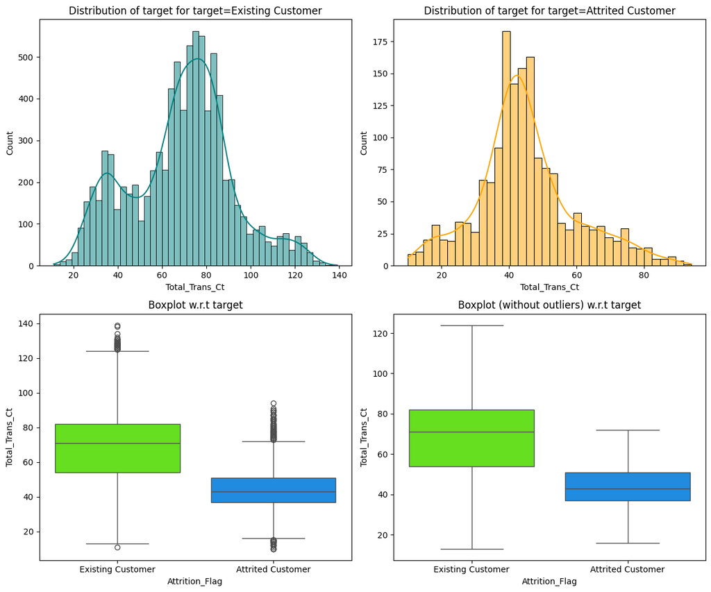

```python
distribution_plot_wrt_target(data, 'Total_Trans_Ct', 'Attrition_Flag')
```

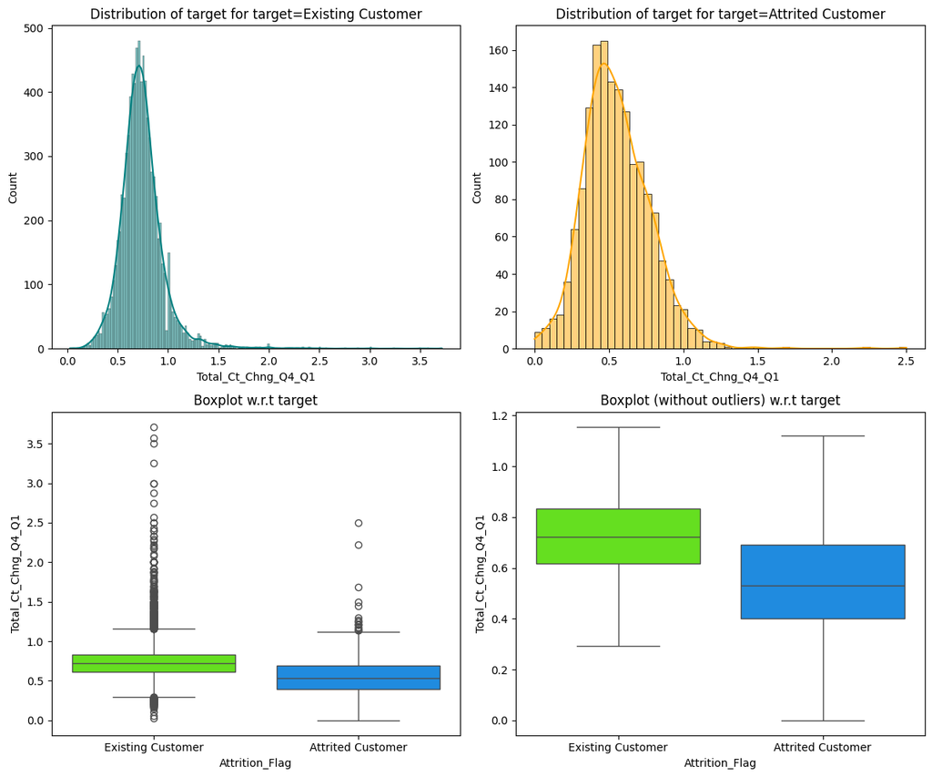

```python
distribution_plot_wrt_target(data, 'Total_Ct_Chng_Q4_Q1', 'Attrition_Flag')
```

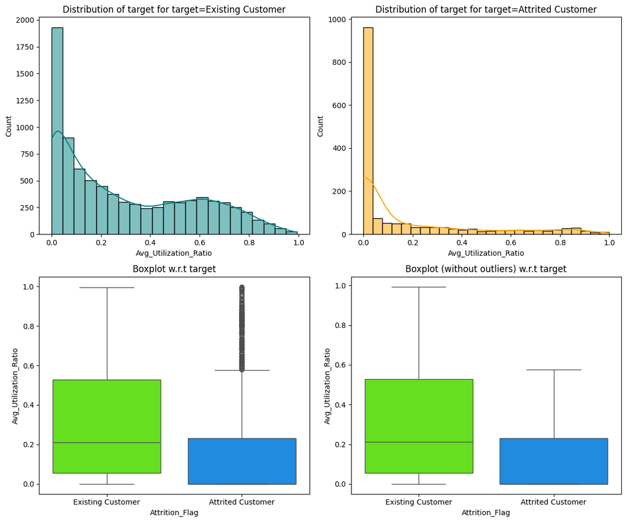

```python
distribution_plot_wrt_target(data, 'Avg_Utilization_Ratio', 'Attrition_Flag')
```

#### Categorical Variables

```
Attrition_Flag  Attrited Customer  Existing Customer    All
Gender
All                          1627               8500  10127
F                             930               4428   5358
M                             697               4072   4769
------------------------------------------------------------------------------------------------------------------------
```

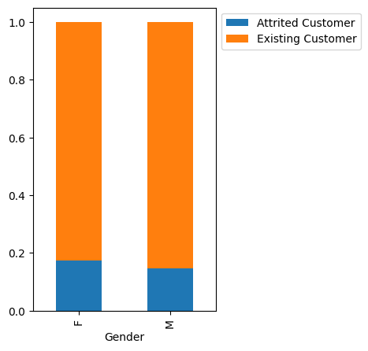

```python
stacked_barplot(data, 'Gender', 'Attrition_Flag')
```

```
Attrition_Flag   Attrited Customer  Existing Customer    All
Dependent_count
All                           1627               8500  10127
3                              482               2250   2732
2                              417               2238   2655
1                              269               1569   1838
4                              260               1314   1574
0                              135                769    904
5                               64                360    424
------------------------------------------------------------------------------------------------------------------------
```

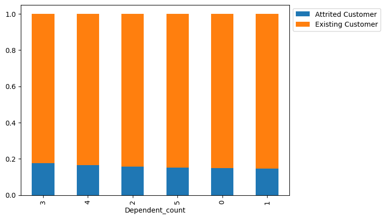

```python
# Even though Dependent_count is technically a numerical variables, there are so few values, it can be instructure to view as a categorical variable.
stacked_barplot(data, 'Dependent_count', 'Attrition_Flag')
```

```
Attrition_Flag   Attrited Customer  Existing Customer   All
Education_Level
All                           1371               7237  8608
Graduate                       487               2641  3128
High School                    306               1707  2013
Uneducated                     237               1250  1487
College                        154                859  1013
Doctorate                       95                356   451
Post-Graduate                   92                424   516
------------------------------------------------------------------------------------------------------------------------
```

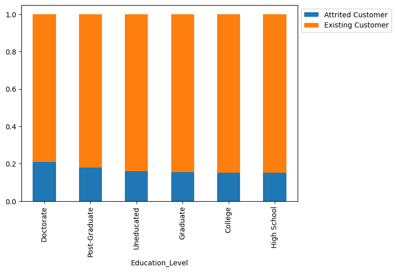

```python
stacked_barplot(data, 'Education_Level', 'Attrition_Flag')
```

```
Attrition_Flag  Attrited Customer  Existing Customer   All
Marital_Status
All                          1498               7880  9378
Married                       709               3978  4687
Single                        668               3275  3943
Divorced                      121                627   748
------------------------------------------------------------------------------------------------------------------------
```

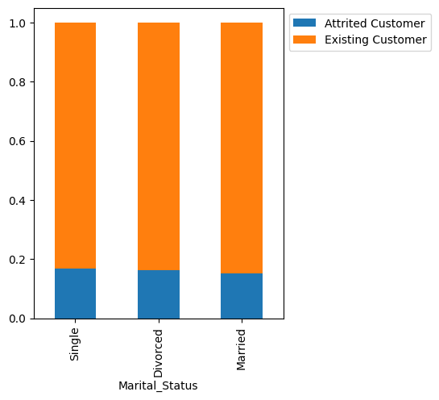

```python
stacked_barplot(data, 'Marital_Status', 'Attrition_Flag')
```

```
Attrition_Flag   Attrited Customer  Existing Customer    All
Income_Category
All                           1627               8500  10127
Less than $40K                 612               2949   3561
$40K - $60K                    271               1519   1790
$80K - $120K                   242               1293   1535
$60K - $80K                    189               1213   1402
abc                            187                925   1112
$120K +                        126                601    727
------------------------------------------------------------------------------------------------------------------------
```

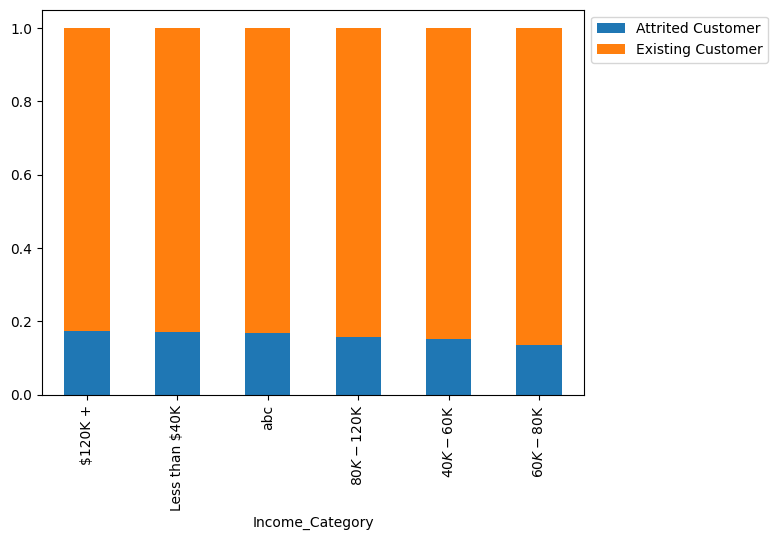

```python
stacked_barplot(data, 'Income_Category', 'Attrition_Flag')
```

```
Attrition_Flag  Attrited Customer  Existing Customer    All
Card_Category
All                          1627               8500  10127
Blue                         1519               7917   9436
Silver                         82                473    555
Gold                           21                 95    116
Platinum                        5                 15     20
------------------------------------------------------------------------------------------------------------------------
```

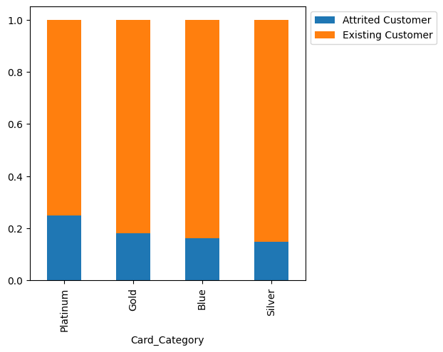

```python
stacked_barplot(data, 'Card_Category', 'Attrition_Flag')
```

## Data Pre-processing

### Missing value imputation

As noted earlier, Education_Level and Martial_Status, have a small percentage of missing values. Income_Category also has missing values which appear as 'abc'. There are missing Education_Level values which show up as 'N/A'.

Based on our stacked bar plot of Education_Level and Attrition_Flag, we saw that Uneducated, High School, College, and Graduate all had about the same prevalence of Attrited Customer, so let's set the missing values here to the mode which is Graduate.

```python
# Set NaN values of Education_Level to 'Graduate'
data['Education_Level'] = data['Education_Level'].fillna('Graduate')
```

```python
print(data.Education_Level.value_counts(dropna=False))
```

```
Education_Level
Graduate         4647
High School      2013
Uneducated       1487
College          1013
Post-Graduate     516
Doctorate         451
Name: count, dtype: int64
```

Based on our stacked bar plot of Marital_status and Attrition_Flag, we saw that the three values all had about the same prevalence of Attrited Customer, so let's set the missing values here to the mode which is Married.

```python
# Set NaN values of Education_Level to 'Graduate'
data['Marital_Status'] = data['Marital_Status'].fillna('Married')
```

```python
print(data.Marital_Status.value_counts(dropna=False))
```

```
Marital_Status
Married     5436
Single      3943
Divorced     748
Name: count, dtype: int64
```

To decide what to do with the abc values in Income_Category, we could reasonably assume some correlation between Income_Category and Total_Trans_Amt and Customer_Age. In the below violin plots we can see that "Less than $40K" is the closest match for Total_Trans_Amt, while for Customer_Age, "Less than $40K" is also a good match. This value also happens to be the mode, so let's go with these value for the missing values.

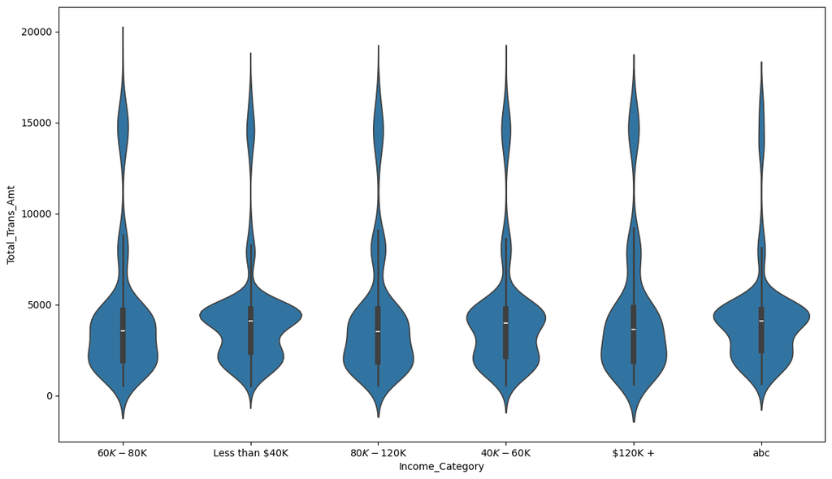

```python
plt.figure(figsize=(14, 8))
sns.violinplot(data=data, x='Income_Category', y='Total_Trans_Amt', orient='v');
```

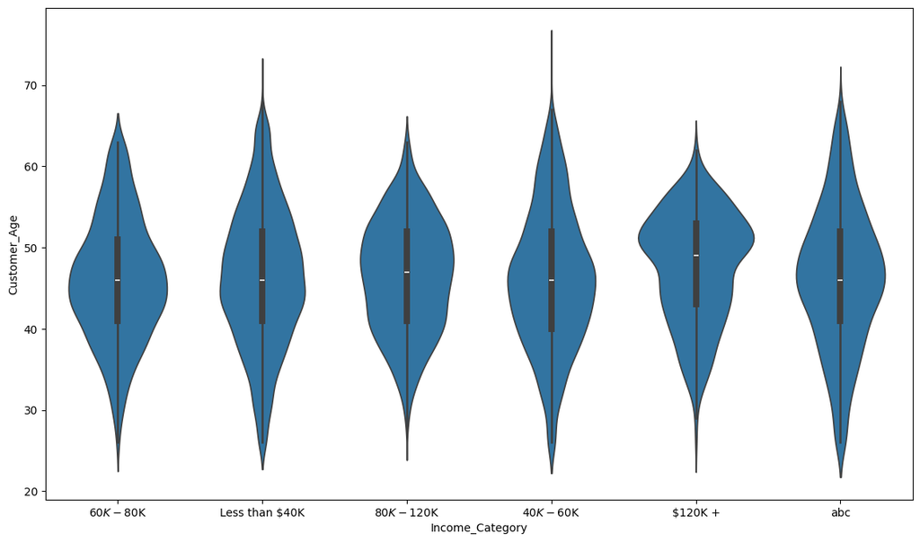

```python
plt.figure(figsize=(14, 8))
sns.violinplot(data=data, x='Income_Category', y='Customer_Age', orient='v');
```

```python
# Replace 'abc' with Less than $40K
data['Income_Category'].replace('abc', 'Less than $40K', inplace=True)
```

### Conversion from Object to Category

Lets convert the columns with an 'object' datatype into categorical variables, to reduce the space required to store the dataframe and improve processing efficieny.

```python
for feature in data.columns: # Loop through all columns in the dataframe
    if data[feature].dtype == 'object': # Only apply for columns with categorical strings
        data[feature] = pd.Categorical(data[feature]) # Convert the column to a categorical type
```

```python
# Confirm that column of type object have been converted to category
data.info()
```

```
<class 'pandas.core.frame.DataFrame'>
RangeIndex: 10127 entries, 0 to 10126
Data columns (total 20 columns):
 #   Column                    Non-Null Count  Dtype
---  ------                    --------------  -----
 0   Attrition_Flag            10127 non-null  category
 1   Customer_Age              10127 non-null  int64
 2   Gender                    10127 non-null  category
 3   Dependent_count           10127 non-null  int64
 4   Education_Level           10127 non-null  category
 5   Marital_Status            10127 non-null  category
 6   Income_Category           10127 non-null  category
 7   Card_Category             10127 non-null  category
 8   Months_on_book            10127 non-null  int64
 9   Total_Relationship_Count  10127 non-null  int64
 10  Months_Inactive_12_mon    10127 non-null  int64
 11  Contacts_Count_12_mon     10127 non-null  int64
 12  Credit_Limit              10127 non-null  float64
 13  Total_Revolving_Bal       10127 non-null  int64
 14  Avg_Open_To_Buy           10127 non-null  float64
 15  Total_Amt_Chng_Q4_Q1      10127 non-null  float64
 16  Total_Trans_Amt           10127 non-null  int64
 17  Total_Trans_Ct            10127 non-null  int64
 18  Total_Ct_Chng_Q4_Q1       10127 non-null  float64
 19  Avg_Utilization_Ratio     10127 non-null  float64
dtypes: category(6), float64(5), int64(9)
memory usage: 1.1 MB
```

```python
print(data.Attrition_Flag.value_counts(dropna=False))
print()
print(data.Gender.value_counts(dropna=False))
print()
print(data.Education_Level.value_counts(dropna=False))
print()
print(data.Marital_Status.value_counts(dropna=False))
print()
print(data.Income_Category.value_counts(dropna=False))
print()
print(data.Card_Category.value_counts(dropna=False))
```

```
Attrition_Flag
Existing Customer    8500
Attrited Customer    1627
Name: count, dtype: int64

Gender
F    5358
M    4769
Name: count, dtype: int64

Education_Level
Graduate         4647
High School      2013
Uneducated       1487
College          1013
Post-Graduate     516
Doctorate         451
Name: count, dtype: int64

Marital_Status
Married     5436
Single      3943
Divorced     748
Name: count, dtype: int64

Income_Category
Less than $40K    4673
$40K - $60K       1790
$80K - $120K      1535
$60K - $80K       1402
$120K +            727
Name: count, dtype: int64

Card_Category
Blue        9436
Silver       555
Gold         116
Platinum      20
Name: count, dtype: int64
```

```python
print(data.Income_Category.value_counts(dropna=False))
```

```
Income_Category
Less than $40K    4673
$40K - $60K       1790
$80K - $120K      1535
$60K - $80K       1402
$120K +            727
Name: count, dtype: int64
```

### One-Hot Encoding

```python
replaceStruct = {
                "Attrition_Flag": {"Existing Customer": 1, "Attrited Customer": 2},
                "Gender": {"M": 1, "F":2},
                 "Education_Level": {"Uneducated": 1, "High School":2 , "College": 3, "Graduate": 4, "Post-Graduate": 5,"Doctorate": 6},
                 "Marital_Status": {"Married": 1, "Single":2 , "Divorced": 3},
                 "Income_Category":     {"Less than $40K": 1, "$40K - $60K": 2 ,"$60K - $80K": 3 ,"$80K - $120K": 4 ,"$120K +": 5},
                "Card_Category":     {"Blue": 1, "Silver": 2, "Gold": 3, "Platinum": 4 }
                    }
oneHotCols=["Attrition_Flag","Gender","Education_Level","Marital_Status","Income_Category", "Card_Category"]
```

```python
data=data.replace(replaceStruct)
data=pd.get_dummies(data, columns=oneHotCols, drop_first=True)
data.head(10)
```

[output not shown]

### Outlier Treatment

Although some of the variables have outliers as event in the EDA, we will keep these values since they are valid data.

## Model Building

### Model evaluation criterion

**Let's define a function to output different metrics (including recall) on the train and test set and a function to show confusion matrix so that we do not have to use the same code repetitively while evaluating models.**

```python
# defining a function to compute different metrics to check performance of a classification model built using sklearn
def model_performance_classification_sklearn(model, predictors, target):
    """
    Function to compute different metrics to check classification model performance

    model: classifier
    predictors: independent variables
    target: dependent variable
    """

    # predicting using the independent variables
    pred = model.predict(predictors)

    acc = accuracy_score(target, pred)  # to compute Accuracy
    recall = recall_score(target, pred)  # to compute Recall
    precision = precision_score(target, pred)  # to compute Precision
    f1 = f1_score(target, pred)  # to compute F1-score

    # creating a dataframe of metrics
    df_perf = pd.DataFrame(
        {
            "Accuracy": acc,
            "Recall": recall,
            "Precision": precision,
            "F1": f1

        },
        index=[0],
    )

    return df_perf
```

```python
def plot_confusion_matrix(model, predictors, target):
    """
    To plot the confusion_matrix with percentages
    model: classifier
    predictors: independent variables
    target: dependent variable
    """
    # Predict the target values using the provided model and predictors
    y_pred = model.predict(predictors)
    # Compute the confusion matrix comparing the true target values with the predicted values
    cm = confusion_matrix(target, y_pred)
    # Create labels for each cell in the confusion matrix with both count and percentage
    labels = np.asarray(
        [
            ["{0:0.0f}".format(item) + "\n{0:.2%}".format(item / cm.flatten().sum())]
            for item in cm.flatten()
        ]
    ).reshape(2, 2)    # reshaping to a matrix
    # Set the figure size for the plot
    plt.figure(figsize=(6, 4))
    # Plot the confusion matrix as a heatmap with the labels
    sns.heatmap(cm, annot=labels, fmt="")
    # Add a label to the y-axis
    plt.ylabel("True label")
    # Add a label to the x-axis
    plt.xlabel("Predicted label")
```

### Split the data into train and test sets

- Since we have an imbalance in the distribution of the target class (Attrition_Flag), it is good to use stratified sampling to ensure that relative class frequencies are approximately preserved in train and test sets.
- We do this by setting the `stratify` parameter to target variable in the train_test_split function.

```python
X = data.drop("Attrition_Flag_1" , axis=1)
y = data.pop("Attrition_Flag_1")
```

```python
X_train, X_test, y_train, y_test = train_test_split(X, y, test_size=.30, random_state=1,stratify=y)
```

```python
#Show the proportion of value in y
y_train.value_counts(normalize=False)
```

| Attrition_Flag_1 | count |
| --- | --- |
| True | 5949 |
| False | 1139 |

**dtype:** int64

Note: For this project I elected to go with the simpler approach of using just a Train and Test split. I acknowledge though another approach is to split the data per Train, Validation, and Test, where Test can be reserved for a check on the final best model.

### Model Building with Original data

Build 5 models (from decision trees, bagging and boosting methods) - Comment on the model performance * You can choose NOT to build XGBoost if you are facing issues with the installation

#### Bagging

```python
bagging_estimator=BaggingClassifier(random_state=1)
bagging_estimator.fit(X_train,y_train)
```

```
BaggingClassifier(random_state=1)
```

```python
bagging_estimator_train_perf = model_performance_classification_sklearn(bagging_estimator, X_train, y_train)
print("Training performance \n",bagging_estimator_train_perf)
```

```
Training performance
    Accuracy  Recall  Precision   F1
0      1.00    1.00       1.00 1.00
```

```python
bagging_estimator_test_perf = model_performance_classification_sklearn(bagging_estimator, X_test, y_test)
print("Testing performance \n",bagging_estimator_test_perf)
```

```
Testing performance
    Accuracy  Recall  Precision   F1
0      0.95    0.97       0.97 0.97
```

#### Random Forest

```python
rf = RandomForestClassifier(random_state=1)
rf.fit(X_train,y_train)
```

```
RandomForestClassifier(random_state=1)
```

```python
rf_train_perf = model_performance_classification_sklearn(rf, X_train, y_train)
print("Training performance \n",rf_train_perf)
```

```
Training performance
    Accuracy  Recall  Precision   F1
0      1.00    1.00       1.00 1.00
```

```python
rf_test_perf = model_performance_classification_sklearn(rf, X_test, y_test)
print("Testing performance \n",rf_test_perf)
```

```
Testing performance
    Accuracy  Recall  Precision   F1
0      0.95    0.99       0.96 0.97
```

#### AdaBoost

```python
ab_regressor = AdaBoostClassifier(random_state=1)
ab_regressor.fit(X_train,y_train)
```

```
AdaBoostClassifier(random_state=1)
```

```python
#Train performance
ab_regressor_train_perf = model_performance_classification_sklearn(ab_regressor, X_train, y_train)
print("Training performance \n",ab_regressor_train_perf)
```

```
Training performance
    Accuracy  Recall  Precision   F1
0      0.96    0.98       0.97 0.98
```

```python
#Test performance
ab_regressor_test_perf = model_performance_classification_sklearn(ab_regressor, X_test, y_test)
print("Testing performance \n",ab_regressor_test_perf)
```

```
Testing performance
    Accuracy  Recall  Precision   F1
0      0.96    0.98       0.97 0.98
```

#### GradientBoosting

```python
#GradientBoost Classifier
gb_estimator = GradientBoostingClassifier(random_state=1)
gb_estimator.fit(X_train,y_train)
```

```
GradientBoostingClassifier(random_state=1)
```

```python
#Train performance
gb_estimator_train_perf = model_performance_classification_sklearn(gb_estimator, X_train, y_train)
print("Training performance \n",gb_estimator_train_perf)
```

```
Training performance
    Accuracy  Recall  Precision   F1
0      0.98    0.99       0.98 0.99
```

```python
#Test performance
gb_estimator_test_perf = model_performance_classification_sklearn(gb_estimator, X_test, y_test)
print("Testing performance \n",gb_estimator_test_perf)
```

```
Testing performance
    Accuracy  Recall  Precision   F1
0      0.96    0.99       0.97 0.98
```

#### Decision Tree

```python
dtree=DecisionTreeClassifier(random_state=1)
dtree.fit(X_train,y_train)
```

```
DecisionTreeClassifier(random_state=1)
```

```python
dtree_model_train_perf = model_performance_classification_sklearn(dtree, X_train, y_train)
print("Training performance \n",dtree_model_train_perf)
```

```
Training performance
    Accuracy  Recall  Precision   F1
0      1.00    1.00       1.00 1.00
```

```python
dtree_model_test_perf = model_performance_classification_sklearn(dtree, X_test, y_test)
print("Testing performance \n",dtree_model_test_perf)
```

```
Testing performance
    Accuracy  Recall  Precision   F1
0      0.94    0.96       0.96 0.96
```

### Model Building with Oversampled data

Oversample the train data - Build 5 models (from decision trees, bagging and boosting methods) - Comment on the model performance * You can choose NOT to build XGBoost if you are facing issues with the installation

```python
# Synthetic Minority Over Sampling Technique
sm = SMOTE(sampling_strategy=1, k_neighbors=5, random_state=1)
X_train_over, y_train_over = sm.fit_resample(X_train, y_train)
```

```python
print("Before OverSampling, count of label '1': {}".format(sum(y_train == 1)))
print("Before OverSampling, count of label '0': {} \n".format(sum(y_train == 0)))

print("After OverSampling, count of label '1': {}".format(sum(y_train_over == 1)))
print("After OverSampling, count of label '0': {} \n".format(sum(y_train_over == 0)))

print("After OverSampling, the shape of train_X: {}".format(X_train_over.shape))
print("After OverSampling, the shape of train_y: {} \n".format(y_train_over.shape))
```

```
Before OverSampling, count of label '1': 5949
Before OverSampling, count of label '0': 1139

After OverSampling, count of label '1': 5949
After OverSampling, count of label '0': 5949

After OverSampling, the shape of train_X: (11898, 30)
After OverSampling, the shape of train_y: (11898,)
```

#### Bagging (Over Sampled)

```python
bagging_estimator_o=BaggingClassifier(random_state=1)
bagging_estimator_o.fit(X_train_over,y_train_over)
```

```
BaggingClassifier(random_state=1)
```

```python
bagging_estimator_o_train_perf = model_performance_classification_sklearn(bagging_estimator_o, X_train_over, y_train_over)
print("Training performance \n",bagging_estimator_o_train_perf)
```

```
Training performance
    Accuracy  Recall  Precision   F1
0      1.00    1.00       1.00 1.00
```

```python
bagging_estimator_o_test_perf = model_performance_classification_sklearn(bagging_estimator_o, X_test, y_test)
print("Testing performance \n",bagging_estimator_o_test_perf)
```

```
Testing performance
    Accuracy  Recall  Precision   F1
0      0.95    0.96       0.98 0.97
```

#### Random Forest (Over Sampled)

```python
rf_o = RandomForestClassifier(random_state=1)
rf_o.fit(X_train_over,y_train_over)
```

```
RandomForestClassifier(random_state=1)
```

```python
rf_train_perf_o = model_performance_classification_sklearn(rf_o, X_train_over, y_train_over)
print("Training performance \n",rf_train_perf_o)
```

```
Training performance
    Accuracy  Recall  Precision   F1
0      1.00    1.00       1.00 1.00
```

```python
rf_test_perf_o = model_performance_classification_sklearn(rf_o, X_test, y_test)
print("Testing performance \n",rf_test_perf_o)
```

```
Testing performance
    Accuracy  Recall  Precision   F1
0      0.96    0.97       0.98 0.97
```

#### AdaBoost (Over Sampled)

```python
ab_regressor_o = AdaBoostClassifier(random_state=1)
ab_regressor_o.fit(X_train_over,y_train_over)
```

```
AdaBoostClassifier(random_state=1)
```

```python
#Train performance
ab_regressor_o_train_perf = model_performance_classification_sklearn(ab_regressor_o, X_train_over, y_train_over)
print("Training performance \n",ab_regressor_o_train_perf)
```

```
Training performance
    Accuracy  Recall  Precision   F1
0      0.96    0.96       0.96 0.96
```

```python
#Test performance
ab_regressor_o_test_perf = model_performance_classification_sklearn(ab_regressor_o, X_test, y_test)
print("Testing performance \n",ab_regressor_o_test_perf)
```

```
Testing performance
    Accuracy  Recall  Precision   F1
0      0.95    0.96       0.98 0.97
```

#### GradientBoosting (Over Sampled)

```python
#GradientBoost Classifier
gb_estimator_o = GradientBoostingClassifier(random_state=1)
gb_estimator_o.fit(X_train_over,y_train_over)
```

```
GradientBoostingClassifier(random_state=1)
```

```python
#Train performance
gb_estimator_o_train_perf = model_performance_classification_sklearn(gb_estimator_o, X_train_over, y_train_over)
print("Training performance \n",gb_estimator_o_train_perf)
```

```
Training performance
    Accuracy  Recall  Precision   F1
0      0.98    0.97       0.98 0.98
```

```python
#Test performance
gb_estimator_o_test_perf = model_performance_classification_sklearn(gb_estimator_o, X_test, y_test)
print("Testing performance \n",gb_estimator_o_test_perf)
```

```
Testing performance
    Accuracy  Recall  Precision   F1
0      0.96    0.97       0.98 0.98
```

#### Decision Tree (Over Sampled)

```python
dtree_o=DecisionTreeClassifier(random_state=1)
dtree_o.fit(X_train_over,y_train_over)
```

```
DecisionTreeClassifier(random_state=1)
```

```python
dtree_model_o_train_perf = model_performance_classification_sklearn(dtree_o, X_train_over, y_train_over)
print("Training performance \n",dtree_model_o_train_perf)
```

```
Training performance
    Accuracy  Recall  Precision   F1
0      1.00    1.00       1.00 1.00
```

```python
dtree_model_o_test_perf = model_performance_classification_sklearn(dtree_o, X_test, y_test)
print("Testing performance \n",dtree_model_o_test_perf)
```

```
Testing performance
    Accuracy  Recall  Precision   F1
0      0.93    0.95       0.97 0.96
```

### Model Building with Undersampled data

Undersample the train data - Build 5 models (from decision trees, bagging and boosting methods) - Comment on the model performance * You can choose NOT to build XGBoost if you are facing issues with the installation

```python
# Random undersampler for under sampling the data
rus = RandomUnderSampler(random_state=1, sampling_strategy=1)
X_train_un, y_train_un = rus.fit_resample(X_train, y_train)
```

```python
print("Before UnderSampling, count of label '1': {}".format(sum(y_train == 1)))
print("Before UnderSampling, count of label '0': {} \n".format(sum(y_train == 0)))

print("After UnderSampling, count of label '1': {}".format(sum(y_train_un == 1)))
print("After UnderSampling, count of label '0': {} \n".format(sum(y_train_un == 0)))

print("After UnderSampling, the shape of train_X: {}".format(X_train_un.shape))
print("After UnderSampling, the shape of train_y: {} \n".format(y_train_un.shape))
```

```
Before UnderSampling, count of label '1': 5949
Before UnderSampling, count of label '0': 1139

After UnderSampling, count of label '1': 1139
After UnderSampling, count of label '0': 1139

After UnderSampling, the shape of train_X: (2278, 30)
After UnderSampling, the shape of train_y: (2278,)
```

#### Bagging (Under Sampled)

```python
bagging_estimator_u=BaggingClassifier(random_state=1)
bagging_estimator_u.fit(X_train_un,y_train_un)
```

```
BaggingClassifier(random_state=1)
```

```python
bagging_estimator_u_train_perf = model_performance_classification_sklearn(bagging_estimator_u, X_train_un, y_train_un)
print("Training performance \n",bagging_estimator_u_train_perf)
```

```
Training performance
    Accuracy  Recall  Precision   F1
0      1.00    0.99       1.00 1.00
```

```python
bagging_estimator_u_test_perf = model_performance_classification_sklearn(bagging_estimator_u, X_test, y_test)
print("Testing performance \n",bagging_estimator_u_test_perf)
```

```
Testing performance
    Accuracy  Recall  Precision   F1
0      0.91    0.91       0.98 0.95
```

#### Random Forest (Under Sampled)

```python
rf_u = RandomForestClassifier(random_state=1)
rf_u.fit(X_train_un,y_train_un)
```

```
RandomForestClassifier(random_state=1)
```

```python
rf_train_perf_u = model_performance_classification_sklearn(rf_u, X_train_un, y_train_un)
print("Training performance \n",rf_train_perf_u)
```

```
Training performance
    Accuracy  Recall  Precision   F1
0      1.00    1.00       1.00 1.00
```

```python
rf_test_perf_u = model_performance_classification_sklearn(rf_u, X_test, y_test)
print("Testing performance \n",rf_test_perf_u)
```

```
Testing performance
    Accuracy  Recall  Precision   F1
0      0.92    0.92       0.99 0.95
```

#### AdaBoost (Under Sampled)

```python
ab_regressor_u = AdaBoostClassifier(random_state=1)
ab_regressor_u.fit(X_train_un,y_train_un)
```

```
AdaBoostClassifier(random_state=1)
```

```python
#Train performance
ab_regressor_u_train_perf = model_performance_classification_sklearn(ab_regressor_u, X_train_un, y_train_un)
print("Training performance \n",ab_regressor_u_train_perf)
```

```
Training performance
    Accuracy  Recall  Precision   F1
0      0.95    0.95       0.96 0.95
```

```python
#Test performance
ab_regressor_u_test_perf = model_performance_classification_sklearn(ab_regressor_u, X_test, y_test)
print("Testing performance \n",ab_regressor_u_test_perf)
```

```
Testing performance
    Accuracy  Recall  Precision   F1
0      0.93    0.93       0.99 0.96
```

#### GradientBoosting (Under Sampled)

```python
#GradientBoost Classifier
gb_estimator_u = GradientBoostingClassifier(random_state=1)
gb_estimator_u.fit(X_train_un,y_train_un)
```

```
GradientBoostingClassifier(random_state=1)
```

```python
#Train performance
gb_estimator_u_train_perf = model_performance_classification_sklearn(gb_estimator_u, X_train_un, y_train_un)
print("Training performance \n",gb_estimator_u_train_perf)
```

```
Training performance
    Accuracy  Recall  Precision   F1
0      0.98    0.97       0.98 0.98
```

```python
#Test performance
gb_estimator_u_test_perf = model_performance_classification_sklearn(gb_estimator_u, X_test, y_test)
print("Testing performance \n",gb_estimator_u_test_perf)
```

```
Testing performance
    Accuracy  Recall  Precision   F1
0      0.95    0.95       0.99 0.97
```

#### Decision Tree (Under Sampled)

```python
dtree_u=DecisionTreeClassifier(random_state=1)
dtree_u.fit(X_train_un,y_train_un)
```

```
DecisionTreeClassifier(random_state=1)
```

```python
dtree_model_u_train_perf = model_performance_classification_sklearn(dtree_u, X_train_un, y_train_un)
print("Training performance \n",dtree_model_o_train_perf)
```

```
Training performance
    Accuracy  Recall  Precision   F1
0      1.00    1.00       1.00 1.00
```

```python
dtree_model_u_test_perf = model_performance_classification_sklearn(dtree_u, X_test, y_test)
print("Testing performance \n",dtree_model_u_test_perf)
```

```
Testing performance
    Accuracy  Recall  Precision   F1
0      0.90    0.91       0.98 0.94
```

### Model Comparison to Choose Best 3 Models for Next Step

```python
# training performance comparison

models_train_comp_df = pd.concat(
    [bagging_estimator_train_perf.T, bagging_estimator_o_train_perf.T, bagging_estimator_u_train_perf.T,
    rf_train_perf.T, rf_train_perf_o.T, rf_train_perf_u.T,
     ab_regressor_train_perf.T, ab_regressor_o_train_perf.T, ab_regressor_u_train_perf.T,
     gb_estimator_train_perf.T, gb_estimator_o_train_perf.T, gb_estimator_u_train_perf.T,
     dtree_model_train_perf.T, dtree_model_o_train_perf.T, dtree_model_u_train_perf.T],
    axis=1,
)

models_train_comp_df.columns = [
    "Bagging Estimator",
    "Bagging Estimator O",
    "Bagging Estimator U",
    "Random Forest",
    "Random Forest O",
    "Random Forest U",
    "AdaBoost",
    "AdaBoost O",
    "AdaBoost U",
    "GradientBoost",
    "GradientBoost O",
    "GradientBoost U",
    "Decision Tree",
    "Decision Tree O",
    "Decision Tree U"
]

# Sort columns based on the 'Recall' row
models_train_comp_df = models_train_comp_df.T.sort_values(by='Recall', ascending=False).T


print("Training performance comparison:")
models_train_comp_df
```

```
Training performance comparison:
```

|  | Random Forest | Random Forest O | Random Forest U | Decision Tree | Decision Tree O | Decision Tree U | Bagging Estimator | Bagging Estimator O | Bagging Estimator U | GradientBoost | AdaBoost | GradientBoost O | GradientBoost U | AdaBoost O | AdaBoost U |
| --- | --- | --- | --- | --- | --- | --- | --- | --- | --- | --- | --- | --- | --- | --- | --- |
| Accuracy | 1.00 | 1.00 | 1.00 | 1.00 | 1.00 | 1.00 | 1.00 | 1.00 | 1.00 | 0.98 | 0.96 | 0.98 | 0.98 | 0.96 | 0.95 |
| Recall | 1.00 | 1.00 | 1.00 | 1.00 | 1.00 | 1.00 | 1.00 | 1.00 | 0.99 | 0.99 | 0.98 | 0.97 | 0.97 | 0.96 | 0.95 |
| Precision | 1.00 | 1.00 | 1.00 | 1.00 | 1.00 | 1.00 | 1.00 | 1.00 | 1.00 | 0.98 | 0.97 | 0.98 | 0.98 | 0.96 | 0.96 |
| F1 | 1.00 | 1.00 | 1.00 | 1.00 | 1.00 | 1.00 | 1.00 | 1.00 | 1.00 | 0.99 | 0.98 | 0.98 | 0.98 | 0.96 | 0.95 |

```python
# test performance comparison

models_test_comp_df = pd.concat(
    [bagging_estimator_test_perf.T, bagging_estimator_o_test_perf.T, bagging_estimator_u_test_perf.T,
    rf_test_perf.T, rf_test_perf_o.T, rf_test_perf_u.T,
     ab_regressor_test_perf.T, ab_regressor_o_test_perf.T, ab_regressor_u_test_perf.T,
     gb_estimator_test_perf.T, gb_estimator_o_test_perf.T, gb_estimator_u_test_perf.T,
     dtree_model_test_perf.T, dtree_model_o_test_perf.T, dtree_model_u_test_perf.T],
    axis=1,
)

models_test_comp_df.columns = [
    "Bagging Estimator",
    "Bagging Estimator O",
    "Bagging Estimator U",
    "Random Forest",
    "Random Forest O",
    "Random Forest U",
    "AdaBoost",
    "AdaBoost O",
    "AdaBoost U",
    "GradientBoost",
    "GradientBoost O",
    "GradientBoost U",
    "Decision Tree",
    "Decision Tree O",
    "Decision Tree U"
]

# Sort columns based on the 'Recall' row
models_test_comp_df = models_test_comp_df.T.sort_values(by='Recall', ascending=False).T


print("Testing performance comparison:")
models_test_comp_df
```

```
Testing performance comparison:
```

|  | Random Forest | GradientBoost | AdaBoost | Random Forest O | GradientBoost O | Bagging Estimator | Decision Tree | Bagging Estimator O | AdaBoost O | Decision Tree O | GradientBoost U | AdaBoost U | Random Forest U | Bagging Estimator U | Decision Tree U |
| --- | --- | --- | --- | --- | --- | --- | --- | --- | --- | --- | --- | --- | --- | --- | --- |
| Accuracy | 0.95 | 0.96 | 0.96 | 0.96 | 0.96 | 0.95 | 0.94 | 0.95 | 0.95 | 0.93 | 0.95 | 0.93 | 0.92 | 0.91 | 0.90 |
| Recall | 0.99 | 0.99 | 0.98 | 0.97 | 0.97 | 0.97 | 0.96 | 0.96 | 0.96 | 0.95 | 0.95 | 0.93 | 0.92 | 0.91 | 0.91 |
| Precision | 0.96 | 0.97 | 0.97 | 0.98 | 0.98 | 0.97 | 0.96 | 0.98 | 0.98 | 0.97 | 0.99 | 0.99 | 0.99 | 0.98 | 0.98 |
| F1 | 0.97 | 0.98 | 0.98 | 0.97 | 0.98 | 0.97 | 0.96 | 0.97 | 0.97 | 0.96 | 0.97 | 0.96 | 0.95 | 0.95 | 0.94 |

- Random Forest
- GradientBoost
- AdaBoost

### HyperparameterTuning

Choose models that might perform better after tuning (tune at least 3 models out of 15 built in the previous steps) - Provide proper reasoning for tuning that model - Tune the best 3 models obtained above using randomized search and metric of interest - Check the performance of 3 tuned models.

#### Sample Parameter Grids

**Note**

1. Sample parameter grids have been provided to do necessary hyperparameter tuning. These sample grids are expected to provide a balance between model performance improvement and execution time. One can extend/reduce the parameter grid based on execution time and system configuration.
- Please note that if the parameter grid is extended to improve the model performance further, the execution time will increase
- For Gradient Boosting:

```
param_grid = {
    "init": [AdaBoostClassifier(random_state=1),DecisionTreeClassifier(random_state=1)],
    "n_estimators": np.arange(50,110,25),
    "learning_rate": [0.01,0.1,0.05],
    "subsample":[0.7,0.9],
    "max_features":[0.5,0.7,1],
}
```

- For Adaboost:

```
param_grid = {
    "n_estimators": np.arange(50,110,25),
    "learning_rate": [0.01,0.1,0.05],
    "base_estimator": [
        DecisionTreeClassifier(max_depth=2, random_state=1),
        DecisionTreeClassifier(max_depth=3, random_state=1),
    ],
}
```

- For Bagging Classifier:

```
param_grid = {
    'max_samples': [0.8,0.9,1],
    'max_features': [0.7,0.8,0.9],
    'n_estimators' : [30,50,70],
}
```

- For Random Forest:

```
param_grid = {
    "n_estimators": [50,110,25],
    "min_samples_leaf": np.arange(1, 4),
    "max_features": [np.arange(0.3, 0.6, 0.1),'sqrt'],
    "max_samples": np.arange(0.4, 0.7, 0.1)
}
```

- For Decision Trees:

```
param_grid = {
    'max_depth': np.arange(2,6),
    'min_samples_leaf': [1, 4, 7],
    'max_leaf_nodes' : [10, 15],
    'min_impurity_decrease': [0.0001,0.001]
}
```

- For XGBoost (optional):

```
param_grid={'n_estimators':np.arange(50,110,25),
            'scale_pos_weight':[1,2,5],
            'learning_rate':[0.01,0.1,0.05],
            'gamma':[1,3],
            'subsample':[0.7,0.9]
}
```

#### Tuning of the Random Forest Model

```python
# defining model
rf = RandomForestClassifier(random_state=1)

# Parameter grid to pass in RandomSearchCV
param_grid = {
    "n_estimators": [50,110,25],
    "min_samples_leaf": np.arange(1, 4),
    "max_features": [np.arange(0.3, 0.6, 0.1),'sqrt'],
    "max_samples": np.arange(0.4, 0.7, 0.1)
}

# Type of scoring used to compare parameter combinations
scorer = metrics.make_scorer(metrics.recall_score)

#Calling RandomizedSearchCV
randomized_cv = RandomizedSearchCV(estimator=rf, param_distributions=param_grid, n_iter=10, n_jobs = -1, scoring=scorer, cv=5, random_state=1)

#Fitting parameters in RandomizedSearchCV
randomized_cv.fit(X_train,y_train)

print("Best parameters are {} with CV score={}:" .format(randomized_cv.best_params_,randomized_cv.best_score_))
```

```
Best parameters are {'n_estimators': 50, 'min_samples_leaf': 2, 'max_samples': 0.4, 'max_features': 'sqrt'} with CV score=0.9873935444657258:
```

```python
# Set the model to the best combination of parameters
rf_tuned = RandomForestClassifier(
    random_state=1,
    n_estimators=50,
    min_samples_leaf=2,
    max_samples=0.4,
    max_features='sqrt'
)

# Fit the best algorithm to the data
rf_tuned.fit(X_train, y_train)
```

```
RandomForestClassifier(max_samples=0.4, min_samples_leaf=2, n_estimators=50,
                       random_state=1)
```

```python
rf_tuned_train_perf = model_performance_classification_sklearn(rf_tuned, X_train, y_train)
print("Training performance \n",rf_tuned_train_perf)
```

```
Training performance
    Accuracy  Recall  Precision   F1
0      0.98    0.99       0.98 0.99
```

```python
rf_tuned_test_perf = model_performance_classification_sklearn(rf_tuned, X_test, y_test)
print("Testing performance \n",rf_tuned_test_perf)
```

[output not shown]

#### Tuning of the GradientBoost Model

```python
# defining model
gb_estimator = GradientBoostingClassifier(random_state=1)

# Parameter grid to pass in RandomSearchCV
param_grid = {
    "init": [AdaBoostClassifier(random_state=1),DecisionTreeClassifier(random_state=1)],
    "n_estimators": np.arange(50,110,25),
    "learning_rate": [0.01,0.1,0.05],
    "subsample":[0.7,0.9],
    "max_features":[0.5,0.7,1],
}

# Type of scoring used to compare parameter combinations
scorer = metrics.make_scorer(metrics.recall_score)

#Calling RandomizedSearchCV
randomized_cv = RandomizedSearchCV(estimator=gb_estimator, param_distributions=param_grid, n_iter=10, n_jobs = -1, scoring=scorer, cv=5, random_state=1)

#Fitting parameters in RandomizedSearchCV
randomized_cv.fit(X_train,y_train)

print("Best parameters are {} with CV score={}:" .format(randomized_cv.best_params_,randomized_cv.best_score_))
```

```
Best parameters are {'subsample': 0.7, 'n_estimators': 50, 'max_features': 1, 'learning_rate': 0.05, 'init': AdaBoostClassifier(random_state=1)} with CV score=0.9996637241944718:
```

```python
# Set the model to the best combination of parameters
gb_estimator_tuned = GradientBoostingClassifier(
    random_state=1,
    subsample=0.7,
    n_estimators=50,
    max_features=1,
    learning_rate=0.05,
    init=AdaBoostClassifier(random_state=1)
)

# Fit the best algorithm to the data
gb_estimator_tuned.fit(X_train, y_train)
```

```
GradientBoostingClassifier(init=AdaBoostClassifier(random_state=1),
                           learning_rate=0.05, max_features=1, n_estimators=50,
                           random_state=1, subsample=0.7)
```

```python
gb_tuned_train_perf = model_performance_classification_sklearn(gb_estimator_tuned, X_train, y_train)
print("Training performance \n",gb_tuned_train_perf)
```

```
Training performance
    Accuracy  Recall  Precision   F1
0      0.86    1.00       0.86 0.92
```

```python
gb_tuned_test_perf = model_performance_classification_sklearn(gb_estimator_tuned, X_test, y_test)
print("Testing performance \n",gb_tuned_test_perf)
```

```
Testing performance
    Accuracy  Recall  Precision   F1
0      0.86    1.00       0.86 0.92
```

#### Tuning of the AdaBoost Model

```python
# defining model
ab = AdaBoostClassifier(random_state=1)

# Parameter grid to pass in RandomSearchCV
param_grid = {
    "n_estimators": np.arange(50,110,25),
    "learning_rate": [0.01,0.1,0.05],
    "base_estimator": [
        DecisionTreeClassifier(max_depth=2, random_state=1),
        DecisionTreeClassifier(max_depth=3, random_state=1),
    ],
}

# Type of scoring used to compare parameter combinations
scorer = metrics.make_scorer(metrics.recall_score)

#Calling RandomizedSearchCV
randomized_cv = RandomizedSearchCV(estimator=ab, param_distributions=param_grid, n_iter=10, n_jobs = -1, scoring=scorer, cv=5, random_state=1)

#Fitting parameters in RandomizedSearchCV
randomized_cv.fit(X_train,y_train)

print("Best parameters are {} with CV score={}:" .format(randomized_cv.best_params_,randomized_cv.best_score_))
```

```
Best parameters are {'n_estimators': 75, 'learning_rate': 0.1, 'base_estimator': DecisionTreeClassifier(max_depth=3, random_state=1)} with CV score=0.9889060081559957:
```

```python
# Set the model to the best combination of parameters
ab_tuned = AdaBoostClassifier(
    random_state=1,
    n_estimators=75,
    learning_rate=0.1,
    base_estimator=DecisionTreeClassifier(max_depth=3, random_state=1)
)

# Fit the best algorithm to the data
ab_tuned.fit(X_train, y_train)
```

```
AdaBoostClassifier(base_estimator=DecisionTreeClassifier(max_depth=3,
                                                         random_state=1),
                   learning_rate=0.1, n_estimators=75, random_state=1)
```

```python
ab_tuned_train_perf = model_performance_classification_sklearn(ab_tuned, X_train, y_train)
print("Training performance \n",ab_tuned_train_perf)
```

```
Training performance
    Accuracy  Recall  Precision   F1
0      0.98    0.99       0.98 0.99
```

```python
ab_tuned_test_perf = model_performance_classification_sklearn(ab_tuned, X_test, y_test)
print("Testing performance \n",ab_tuned_test_perf)
```

```
Testing performance
    Accuracy  Recall  Precision   F1
0      0.97    0.99       0.97 0.98
```

### Final Model Comparison of Tuned Models

```python
# training performance comparison

models_train_comp_df = pd.concat(
    [rf_train_perf.T, rf_tuned_train_perf.T,
     ab_regressor_train_perf.T, ab_tuned_train_perf.T,
     gb_estimator_train_perf.T, gb_tuned_train_perf.T],
    axis=1,
)

models_train_comp_df.columns = [
    "Random Forest",
    "Random Forest Tuned",
    "AdaBoost",
    "AdaBoost Tuned",
    "GradientBoost",
    "GradientBoost Tuned"
]

# Sort columns based on the 'Recall' row
#models_train_comp_df = models_train_comp_df.T.sort_values(by='Recall', ascending=False).T


print("Training performance comparison:")
models_train_comp_df
```

```
Training performance comparison:
```

|  | Random Forest | Random Forest Tuned | AdaBoost | AdaBoost Tuned | GradientBoost | GradientBoost Tuned |
| --- | --- | --- | --- | --- | --- | --- |
| Accuracy | 1.00 | 0.98 | 0.96 | 0.98 | 0.98 | 0.86 |
| Recall | 1.00 | 0.99 | 0.98 | 0.99 | 0.99 | 1.00 |
| Precision | 1.00 | 0.98 | 0.97 | 0.98 | 0.98 | 0.86 |
| F1 | 1.00 | 0.99 | 0.98 | 0.99 | 0.99 | 0.92 |

```python
# testing performance comparison

models_test_comp_df = pd.concat(
    [rf_test_perf.T, rf_tuned_test_perf.T,
     ab_regressor_test_perf.T, ab_tuned_test_perf.T,
     gb_estimator_test_perf.T, gb_tuned_test_perf.T],
    axis=1,
)

models_test_comp_df.columns = [
    "Random Forest",
    "Random Forest Tuned",
    "AdaBoost",
    "AdaBoost Tuned",
    "GradientBoost",
    "GradientBoost Tuned"
]

# Sort columns based on the 'Recall' row
#models_test_comp_df = models_train_comp_df.T.sort_values(by='Recall', ascending=False).T


print("Testing performance comparison:")
models_test_comp_df
```

```
Testing performance comparison:
```

|  | Random Forest | Random Forest Tuned | AdaBoost | AdaBoost Tuned | GradientBoost | GradientBoost Tuned |
| --- | --- | --- | --- | --- | --- | --- |
| Accuracy | 0.95 | 0.94 | 0.96 | 0.97 | 0.96 | 0.86 |
| Recall | 0.99 | 0.99 | 0.98 | 0.99 | 0.99 | 1.00 |
| Precision | 0.96 | 0.95 | 0.97 | 0.97 | 0.97 | 0.86 |
| F1 | 0.97 | 0.97 | 0.98 | 0.98 | 0.98 | 0.92 |

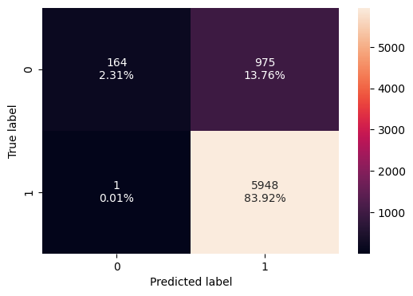

```python
#Train Confusion Matrix
plot_confusion_matrix(gb_estimator_tuned, X_train, y_train)
```

```python
confusion_matrix(y_train, gb_estimator_tuned.predict(X_train))
```

```
array([[ 164,  975],
       [   1, 5948]])
```

```python
confusion_matrix(y_test, gb_estimator_tuned.predict(X_test))
```

```
array([[  61,  427],
       [   0, 2551]])
```

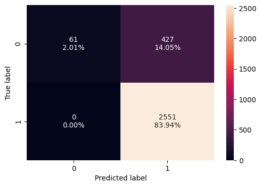

```python
#Test Confusion Matrix
plot_confusion_matrix(gb_estimator_tuned, X_test, y_test)
```

[figure not shown]

```python
feature_names = X_train.columns
importances = gb_estimator_tuned.feature_importances_
indices = np.argsort(importances)
plt.figure(figsize=(12,12))
plt.title('Feature Importances')
plt.barh(range(len(indices)), importances[indices], color='violet', align='center')
plt.yticks(range(len(indices)), [feature_names[i] for i in indices])
plt.xlabel('Relative Importance')
plt.show()
```

# Business Insights and Conclusions

The dominant factors for predicting if a customer will drop their credit cards are:

- Total_Trans_Amt: Total Transaction Amount (Last 12 months)
- Total_Revolving_Bal: The balance that carries over from one month to the next
- Total_Ct_Chng_Q4_Q1: Ratio of the total transaction count in 4th quarter and the total transaction count in the 1st quarter
- Avg_Utilization_Ratio: Represents how much of the available credit the customer spent

Customers with lower Total_Trans_Amt are more likely to drop. Customers with a lower Total_Revolving_Bal are more likely to drop. Customers with a lower Total_Ct_Chng_Q4_Q1 are more likely to drop. Customers with a low Avg_Utilization_Ratio are more likelty to drop.